# ANALYZING THE EFFECT OF VIOLENT VIDEO GAME PLAY ON MATE VALUE AND OTHER MATING RELATED VARIABLES

## General housekeeping

First load the libraries that we are using

```r
library(ggplot2)
library(knitr)
library(QuantPsyc)
library(PerformanceAnalytics)
library(heplots)
library(plyr)
require(gridExtra)
```

```r
data = read.csv(file.choose(),  na.strings =".", header=T, sep=",")
```

Attach and check the headers of each column

```r
names(data)
```

```
##   [1] "study"                       "date"
##   [3] "time"                        "subject"
##   [5] "consentq"                    "last30days"
##   [7] "recentgame1"                 "recentgame2"
##   [9] "recentgame3"                 "recentgame4"
##  [11] "recentgame5"                 "playfrequency1"
##  [13] "playfrequency2"              "playfrequency3"
##  [15] "playfrequency4"              "playfrequency5"
##  [17] "sliderviolence1"             "FreqViolence1"
##  [19] "sliderviolence2"             "FreqViolence2"
##  [21] "sliderviolence3"             "FreqViolence3"
##  [23] "sliderviolence4"             "FreqViolence4"
##  [25] "sliderviolence5"             "FreqViolence5"
##  [27] "Averagefrequencyviolence"    "Age"
##  [29] "Gender"                      "sexnumerical"
```

[output cut: 46 more lines]

Recode gender into numerical values

```r
data$Gender2 <- revalue(data$Gender, c("Male"="1", "Female"="2"))
data$Gender2 <- as.numeric(as.character(data$Gender2))
```

Recode violent/non-violent treatment into numerical values

```r
data$VorNV2 <- revalue(data$VorNV, c("V"="1", "NV"="2"))
data$VorNV2 <- as.numeric(as.character(data$VorNV2))
```

Ensuring that certain columns are treated as categorical

```r
data$Sexuality <- factor(data$Sexuality)
```

Delete Rows where participants were unable to load or play game, had issues with the survey loading, or failed an attention check (27 people). Also delete rows where participants recorded gender as “Other” (4 people).

```r
data<-data[-which(data$Removedata == "Yes"), ]
data<-data[-which(data$Gender == "Other"), ]
```

Remove individuals that have a relationship status of ‘other’ (2 individuals)

```r
data = subset(data, Relationshipstatus %in% c("Single", "In an open relationship/casually dating", "In a long-term monogamous relationship eg. married, partnered", "Recently single/divorced/separated"))
```

Here’s mean centring the data

```r
#data$mc_MV1Total <- scale(data$MV1Total, center = TRUE, scale = TRUE)
#data$mc_SOIRTOTAL <- scale(data$SOIRTOTAL, center = TRUE, scale = TRUE)
#data$mc_MV2Average <- scale(data$MV2Average, center = TRUE, scale = TRUE)
#data$mc_SGAAverage <- scale(data$SGAAverage, center = TRUE, scale = TRUE)
#data$mc_HostilityTotal <- scale(data$HostilityTotal, center = TRUE, scale = TRUE)
#data$mc_MMTotal <- scale(data$MMTotal, center = TRUE, scale = TRUE)
```

First, check the distributions of all the variables of interest

`r hist(data$MV1Total)`

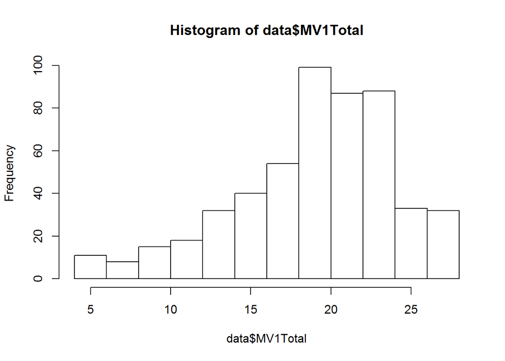

`r hist(data$MV2Average)`

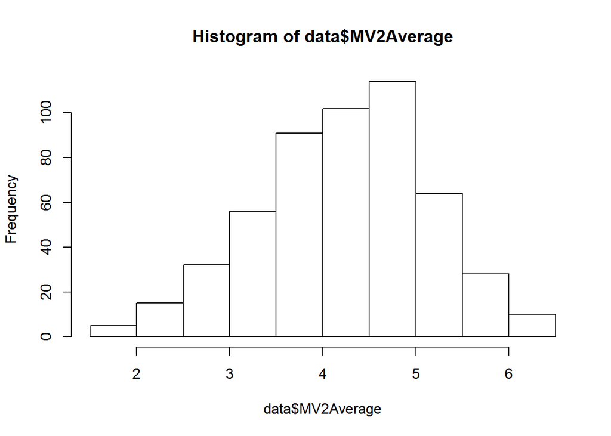

`r hist(data$SGAAverage)`

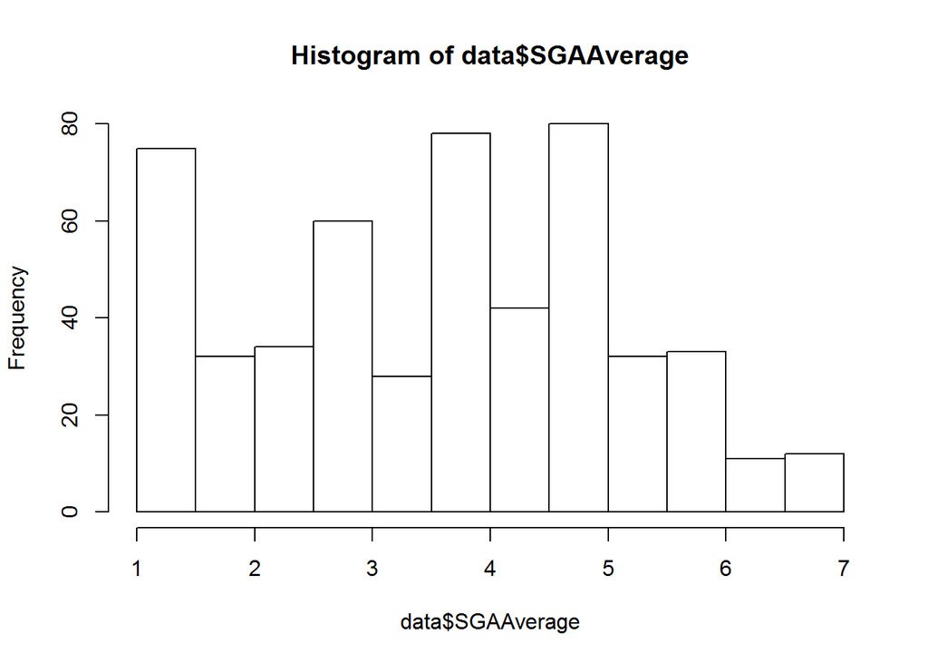

`r hist(data$HostilityTotal)`